# Crime Clustering in Chicago

Alan Zablocki

August 3, 2016

## Setup

We load the required libraries.

```r
library(raster)
```

```r
library(sp)
library(maptools)
gpclibPermit()
```

```
## [1] FALSE
```

```r
library(maptools)
library(mapdata)
library(ggmap)
library(ggplot2)
library(geosphere)
library(maps)
library(animation)
```

Load the theft data for Chicago

```r
mydata  = read.csv("Chicago_crimes_2008_somethefts_only_HP.csv")
head(mydata)
```

```
##                     Date IUCR Primary.Type    Description
## 1 01/12/2015 05:30:00 PM  820        THEFT $500 AND UNDER
## 2 01/12/2015 05:00:00 PM  820        THEFT $500 AND UNDER
## 3 01/12/2015 04:00:00 PM  810        THEFT      OVER $500
## 4 01/12/2015 03:00:00 PM  820        THEFT $500 AND UNDER
## 5 01/12/2015 10:30:00 AM  820        THEFT $500 AND UNDER
## 6 01/12/2015 10:30:00 AM  820        THEFT $500 AND UNDER
##        Location.Description X.Coordinate Y.Coordinate Year Latitude
## 1                    STREET      1183686      1873324 2015 41.80759
## 2                    STREET      1187977      1861520 2015 41.77510
## 3 SCHOOL, PRIVATE, BUILDING      1177517      1872030 2015 41.80418
## 4                    STREET      1180288      1876790 2015 41.81718
## 5                 APARTMENT      1178785      1876973 2015 41.81771
## 6                    STREET      1179760      1874025 2015 41.80960
##   Longitude
## 1 -87.60181
## 2 -87.58645
## 3 -87.62447
## 4 -87.61417
## 5 -87.61967
## 6 -87.61619
```

Select only relevant columns

```r
mydata <- mydata[,c(2,3,5,8,9,10)]
colnames(mydata) <- c("iucr","offense","locat","year","lati","long")
```

Subset data, include street theft only

```r
mydata_STREET_THEFT <- mydata[mydata$locat == "STREET", ]
```

Remove any NAs

```r
mydata_cleaned <- na.omit(mydata_STREET_THEFT)
```

Select 2014 as an example

```r
theft14 <- mydata_cleaned[mydata_cleaned$year == "2014", ]
head(theft14)
```

```
##    iucr offense  locat year     lati      long
## 54  820   THEFT STREET 2014 41.77456 -87.60691
## 55  820   THEFT STREET 2014 41.77623 -87.59747
## 62  820   THEFT STREET 2014 41.80746 -87.61371
## 64  810   THEFT STREET 2014 41.79507 -87.58239
## 72  820   THEFT STREET 2014 41.79952 -87.58140
## 74  820   THEFT STREET 2014 41.80192 -87.62086
```

```r
dim(theft14)
```

```
## [1] 804   6
```

Find the range for long/lat in this dataset

```r
min(abs(theft14[,6]))
```

```
## [1] 87.57012
```

```r
min(abs(theft14[,5]))
```

```
## [1] 41.77001
```

```r
max(abs(theft14[,6]))
```

```
## [1] 87.62915
```

```r
max(abs(theft14[,5]))
```

```
## [1] 41.81997
```

```r
# Get a map of Chicago with appropriate zoom level
require(ggmap)
map_of_Chicago <- get_map(location = c(long = -87.60, lati = 41.80), zoom = 13, maptype = "roadmap", scale = 2)
```

For now we will leave out the highly zoomed in area around the University of Chicago

[figure not shown]

```r
small_plot <- ggmap(map_of_Chicago, extent = "normal", maprange=FALSE) %+% theft14 + aes(x = long, y = lati) + geom_density2d(aes(x = long, y = lati, fill = ..level.. , alpha = ..level..),bins = 25, colour = "black") + coord_map(projection="mercator", xlim=c(-87.607,-87.585), ylim=c(41.785,41.803)) + guides(fill = FALSE,alpha=FALSE,size=FALSE) + geom_point(aes(x = long, y = lati), size = 1, fill = "red", shape = 21)
small_plot
```

```r
# Perform k-means clustering on the whole data set.
# Match x and y axis to long / lati
kmeans_data <- theft14[,6:5]
head(kmeans_data)
```

```
##         long     lati
## 54 -87.60691 41.77456
## 55 -87.59747 41.77623
## 62 -87.61371 41.80746
## 64 -87.58239 41.79507
## 72 -87.58140 41.79952
## 74 -87.62086 41.80192
```

```r
# Find an appropriate number of clusters based on 'elbow' plot
crime0 <- na.omit(kmeans_data)
crime <- data.matrix(crime0)
str(crime)
```

```
##  num [1:804, 1:2] -87.6 -87.6 -87.6 -87.6 -87.6 ...
##  - attr(*, "dimnames")=List of 2
##   ..$ : chr [1:804] "54" "55" "62" "64" ...
##   ..$ : chr [1:2] "long" "lati"
```

```r
cl <- kmeans(crime,5)
class(cl)
```

```
## [1] "kmeans"
```

```r
str(cl)
```

```
## List of 9
##  $ cluster     : Named int [1:804] 1 4 3 5 5 2 1 4 3 1 ...
##   ..- attr(*, "names")= chr [1:804] "54" "55" "62" "64" ...
##  $ centers     : num [1:5, 1:2] -87.6 -87.6 -87.6 -87.6 -87.6 ...
##   ..- attr(*, "dimnames")=List of 2
##   .. ..$ : chr [1:5] "1" "2" "3" "4" ...
##   .. ..$ : chr [1:2] "long" "lati"
##  $ totss       : num 0.31
##  $ withinss    : num [1:5] 0.01345 0.00854 0.01852 0.00992 0.01005
##  $ tot.withinss: num 0.0605
##  $ betweenss   : num 0.25
##  $ size        : int [1:5] 162 136 224 133 149
##  $ iter        : int 5
##  $ ifault      : int 0
##  - attr(*, "class")= chr "kmeans"
```

[figure not shown]

```r
# helper functions to get the 'elbow' plot
kmeans.wss.k <- function(crime, k){
  km = kmeans(crime, k)
  return (km$tot.withinss)
}
kmeans.dis <- function(crime, maxk){
  dis=(nrow(crime)-1)*sum(apply(crime,2,var))
  dis[2:maxk]=sapply (2:maxk, kmeans.wss.k, crime=crime)
  return(dis)
}
```

```r
# Seems like 10 clusters should do it. Let's animate this.
# animation is nice, but takes up a lot of the write up
#cl<- kmeans.ani(kmeans_data, 10)
```

```r
#Examine the cluster plot
#fit1 <- kmeans(crime,10)
#mydata1 <- data.frame(mydata,fit1$cluster)
#aggregate(crime,by=list(fit1$cluster),FUN=mean)
#clusplot(mydata1,fit1$cluster, color = TRUE, shade = TRUE, labels = 2, lines=0)
```

[figure not shown]

```r
# set random seed for reproducing results
# plotting clustered data coloured by cluster solution using k-means
set.seed(1234)
dfX <- data.frame(long=theft14$long,lati=theft14$lati)
km <- kmeans(dfX,centers=10)
kmc <- data.frame(long=km$centers[,1],lati=km$centers[,2])
dfX$clust <- km$cluster
ggmap(map_of_Chicago, extent = "normal", maprange=FALSE) %+% theft14 + aes(x = long, y = lati) + geom_density2d(aes(x = long, y = lati, fill = ..level.. , alpha = ..level..),bins = 25, colour = "black") + coord_map(projection="mercator", xlim=c(-87.63,-87.57), ylim=c(41.77,41.82)) + guides(fill = FALSE,alpha=FALSE,size=FALSE) + geom_point(aes(x = long, y = lati), size = 2, fill = "red", shape = 21) + geom_point(data=dfX, aes(x=long, y=lati, color=factor(clust)), size=2) + geom_point(data=kmc, aes(x=long, y=lati), size=2)
```

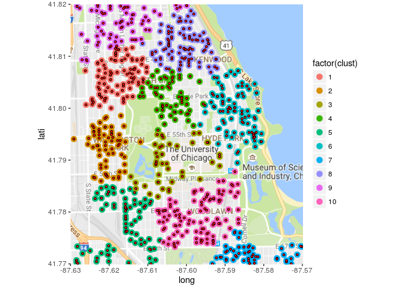

```r
# What if we perform the clustering on distances instead of latitude/longitude pairs?

# helper function

geo.dist = function(df) {
  require(geosphere)
  d <- function(i,z){         # z[1:2] contain long, lat
    dist <- rep(0,nrow(z))
    dist[i:nrow(z)] <- distHaversine(z[i:nrow(z),1:2],z[i,1:2])
    return(dist)
  }
  dm <- do.call(cbind,lapply(1:nrow(df),d,df))
  return(as.dist(dm))
}

df_lat <- data.frame(long=theft14$long,lati=theft14$lati)
df_dist <- geo.dist(df_lat)
set.seed(1234)
km_dist <- kmeans(df_dist,centers = 10)
set.seed(1234)
km_lat <- kmeans(df_lat,centers = 10)
df_with_dist <- data.frame(long=theft14$long,lati=theft14$lati)
df_lat$clust <- km_lat$cluster
df_with_dist$clust <- km_dist$cluster
kmc_lat <- data.frame(long=km_lat$centers[,1],lati=km_lat$centers[,2])
kmc_dist <- data.frame(long=km_dist$centers[,1],lati=km_dist$centers[,2])
# solution based on distances
ggmap(map_of_Chicago, extent = "normal", maprange=FALSE) %+% theft14 + aes(x = long, y = lati) + geom_point(data=df_with_dist, aes(x=long, y=lati, color=factor(clust)), size=3) + geom_point(aes(x = long, y = lati), size = 1, fill = "red", shape = 21) + coord_map(projection="mercator", xlim=c(-87.63,-87.57), ylim=c(41.77,41.82))
```

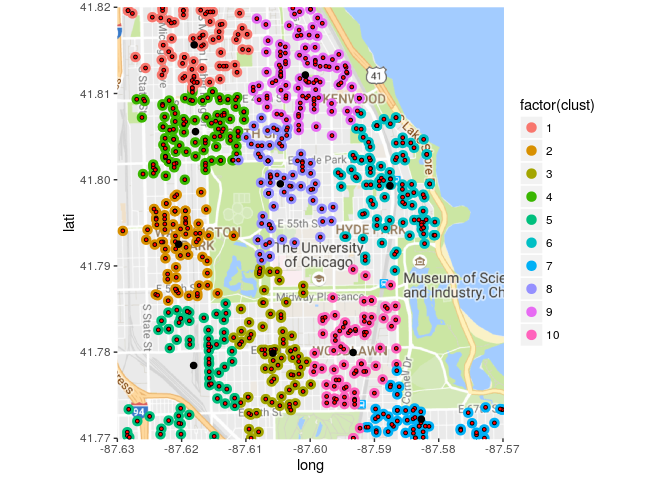

```r
# solution based on long/lat pairs with cluster centres in black
ggmap(map_of_Chicago, extent = "normal", maprange=FALSE) %+% theft14 + aes(x = long, y = lati) + geom_point(data=df_lat, aes(x=long, y=lati, color=factor(clust)), size=3) + geom_point(aes(x = long, y = lati), size = 1, fill = "red", shape = 21) + geom_point(data=kmc_lat, aes(x=long, y=lati), size=2, fill="black") + coord_map(projection="mercator", xlim=c(-87.63,-87.57), ylim=c(41.77,41.82))
```

Performing k-means on crime data with longitude and latitude gives similar results to when we run k-means on distances, but some of the data is assigned to different clusters.

Although, 10 clusters seems like enough, in reality we do care about a maximum distance that a cluster will cover. In the map, we see that each cluster covers a number of blocks, which is not ideal.

The next steps are:

1 - Increase the number of clusters in k-means to cover smaller areas 2 - Perform hierarchical clustering and invetigate a useful upper bound for a cluster 3 - Look at different clustering methods like dbscan, pam, clara and their possible application to this problem. 4 - Analyze clusters for smaller area, immediately surrounding the HP UofC campus

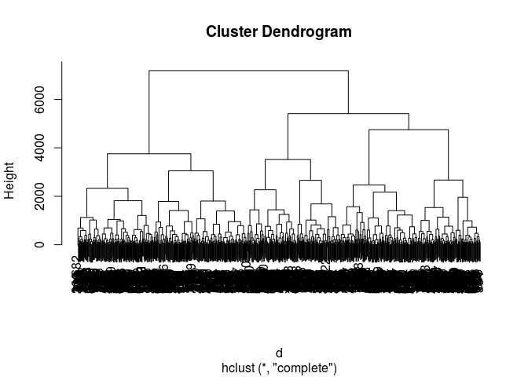

```r
# hierarchial clustering with a cut-off at 10
set.seed(1234)
dfX2 <- data.frame(long=theft14$long,lati=theft14$lati)
d <- geo.dist(dfX2)
hc <- hclust(d)
plot(hc) # plot dendrogram
```

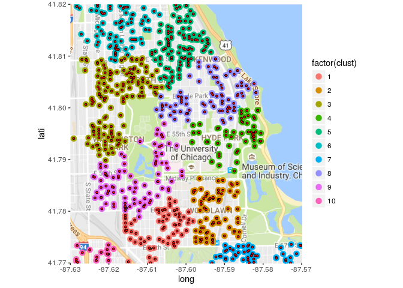

```r
dfX2$clust <- cutree(hc,k=10)
ggmap(map_of_Chicago, extent = "normal", maprange=FALSE) %+% theft14 + aes(x = long, y = lati) + geom_point(data=dfX2, aes(x=long, y=lati, color=factor(clust)), size=3) + geom_point(aes(x = long, y = lati), size = 1, fill = "red", shape = 21) + coord_map(projection="mercator", xlim=c(-87.63,-87.57), ylim=c(41.77,41.82))
```

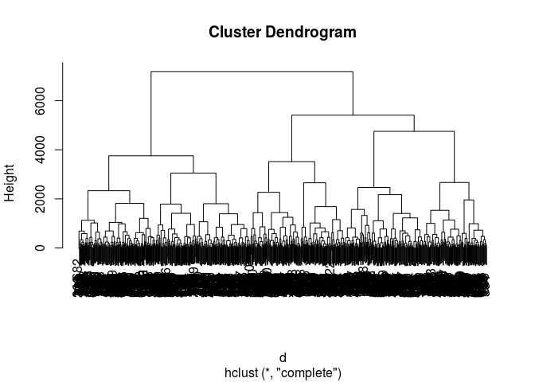

```r
# hierarchial clustering with a cut-off at 40
set.seed(1234)
dfX2 <- data.frame(long=theft14$long,lati=theft14$lati)
d <- geo.dist(dfX2)
hc <- hclust(d)
plot(hc) # plot dendrogram
```

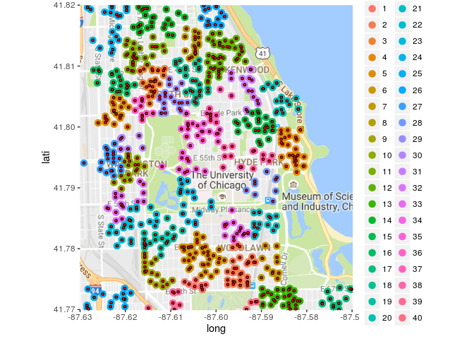

```r
dfX2$clust <- cutree(hc,k=40)
ggmap(map_of_Chicago, extent = "normal", maprange=FALSE) %+% theft14 + aes(x = long, y = lati) + geom_point(data=dfX2, aes(x=long, y=lati, color=factor(clust)), size=3) + geom_point(aes(x = long, y = lati), size = 1, fill = "red", shape = 21) + coord_map(projection="mercator", xlim=c(-87.63,-87.57), ylim=c(41.77,41.82))
```

How does k-means perform for 40 clusters?

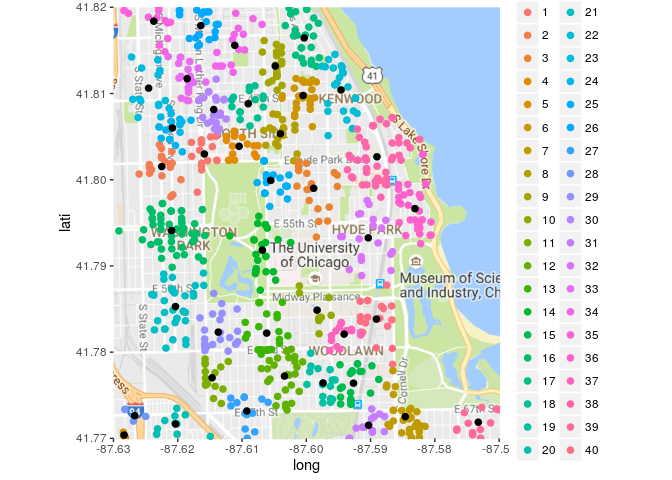

```r
set.seed(1234)
dfX <- data.frame(long=theft14$long,lati=theft14$lati)
km <- kmeans(dfX,centers=40)
kmc <- data.frame(long=km$centers[,1],lati=km$centers[,2])
dfX$clust <- km$cluster
ggmap(map_of_Chicago, extent = "normal", maprange=FALSE) %+% theft14 + aes(x = long, y = lati) + coord_map(projection="mercator", xlim=c(-87.63,-87.57), ylim=c(41.77,41.82)) + guides(fill = FALSE,alpha=FALSE,size=FALSE) + geom_point(data=dfX, aes(x=long, y=lati, color=factor(clust)), size=2) + geom_point(data=kmc, aes(x=long, y=lati), size=2)
```

We end with a coloured heat map with cluster solution using k-means with k=10.

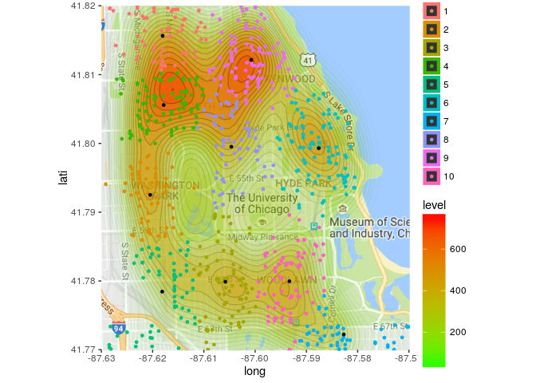

```r
ggmap(map_of_Chicago, extent = "normal", maprange=FALSE) %+% theft14 + aes(x = long, y = lati) + stat_density2d(aes(fill = ..level.., alpha = ..level..),size = 2, bins = 25, geom = 'polygon') + geom_density2d(aes(x = long, y = lati, fill = ..level.. , alpha = ..level..),bins = 25, colour = "black") + scale_fill_gradient(low = "green", high = "red") + scale_alpha(range = c(0.0, 0.25), guide = FALSE) + coord_map(projection="mercator", xlim=c(-87.63,-87.57), ylim=c(41.77,41.82)) + guides(fill = guide_colorbar(barwidth = 1.5, barheight = 10)) + geom_point(data=df_lat, aes(x=long, y=lati, color=factor(clust)), size=1) +geom_point(data=kmc_lat, aes(x=long, y=lati), size=1, fill="black")
```

This kind of analysis has a broad applicability in terms of market use as well as individual use. For example, you could use this to identify crime hotspots, or areas with a lot of traffic accidents to devise safe walking routes for students and school children. I can see this as a great quantitative way of informing house buyers about different areas they might be looking at.

There is informative power for a range of applications, e.g., looking at UChicago campus, there is definitely a bubble - which could be attributed to, for example, good or effective policing.

So we have unsupervised classification as well as detection! In other words this can be used for monitoring practices,e.g., are certain policies (relating to combating crime) effective?